# Introduction to Neural Networks

**Ecole Centrale Nantes**

**Diana Mateus**

**Participants :** Meryam ASSERMOUH - Ikrame HAD

## General description

In this lab we will create a simple classifier based on neural networks. We will progress in two parts:

- In the first part, and to better understand the involved operations, we will create a single-neuron model and optimize its parameters "by hand". For this first part we will only use the **Numpy** library
- We will then build a multi-layer perceptron with the built-in library **Keras** module and **tensorflow**. Tensorflow is already installed in the university computers. If using your own computer you should have already installed **tensorflow** or use **collab** online platform.

```python
import numpy as np
import matplotlib.pyplot as plt
import h5py
```

### Loading the dataset

We start by loading and vizualizing the data.

```python
def load_dataset():
    train_dataset = h5py.File('dataset/dataset/train_catvnoncat.h5', "r")
    train_x = np.array(train_dataset["train_set_x"][:])
    train_y = np.array(train_dataset["train_set_y"][:])
    test_dataset = h5py.File('dataset/dataset/test_catvnoncat.h5', "r")
    test_x = np.array(test_dataset["test_set_x"][:])
    test_y = np.array(test_dataset["test_set_y"][:])
    classes = np.array(test_dataset["list_classes"][:])

    train_y = train_y.reshape((1, train_y.shape[0]))
    test_y = test_y.reshape((1, test_y.shape[0]))

    return train_x, train_y, test_x, test_y, classes

train_x, train_y, test_x, test_y, classes=load_dataset()
```

#### Visualize data

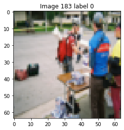

```
Train X shape: (209, 64, 64, 3)
We have 209 images of dimensionality 64x64x3
```

```python
# run several times to visualize different data points
# the title shows the ground truth class labels (0=no cat , 1 = cat)
index = np.random.randint(low=0,high=train_y.shape[1])
plt.imshow(train_x[index])
plt.title("Image "+str(index)+" label "+str(train_y[0,index]))
plt.show()
print ("Train X shape: " + str(train_x.shape))
print ("We have "+str(train_x.shape[0]),
       "images of dimensionality "
       + str(train_x.shape[1])+ "x"
       + str(train_x.shape[2])+ "x"
       + str(train_x.shape[3]))
```

#### Preprocessing

In the following lines we vectorize the images (Instead of a 2-D image we will give as input to the models a 1-D vector). The normalization makes the image intensities be between 0 and 1, and converts the images to floats.

```python
train_x = train_x.reshape(train_x.shape[0], -1).T
test_x = test_x.reshape(test_x.shape[0], -1).T
print ("Train X shape: " + str(train_x.shape))
print ("Train Y shape: " + str(train_y.shape))
print ("Test X shape: " + str(test_x.shape))
print ("Test Y shape: " + str(test_y.shape))
```

```
Train X shape: (12288, 209)
Train Y shape: (1, 209)
Test X shape: (12288, 50)
Test Y shape: (1, 50)
```

```python
train_x = train_x/255.
test_x = test_x/255.
```

### 1. Classification with a single neuron

**a)** We start by defining the single neuron model (a single neuron in the hidden layer), using the following three functions:

- The function **initialize_parameters** of the neuron. It randomly initializes the model's weights with small values. We Initialize the bias with 0. The number of weights required is equal to the length of the image vector.
- A function **sigmoid** which computes the sigmoid activation function
- A function **neuron** that given an input vector, the weights and bias, computes the output of the single neuron model

```python
def sigmoid(z):
    return 1/(1+np.exp(-z))
```

```python
def initialize_parameters(dim):
    w = np.random.rand(dim,1)/1000
    b = 0
    return w, b
```

```python
def neuron(w,b,X):
    pred_y = np.matmul(w.T,X)+b
    pred_y=sigmoid(pred_y)
    return pred_y
```

**b)** **Forward Pass:** We use the three functions above to compute a first forward pass for the input matrix $X$ containing the loaded dataset, for some initialization of the weights and bias.

\begin{align} Y_{\rm pred}=\sigma(w^\top X+b) = [y_{\rm pred}^{(1)},y_{\rm pred}^{(2)},\dots,y_{\rm pred}^{(m)}] \end{align}

```python
w,b=initialize_parameters(12288)
pred_y=neuron(w,b,train_x)
print(pred_y.shape)
```

```
(1, 209)
```

**c) Cost estimation:**

We will use a binary cross-entropy loss, so that the empirical risk can be computed as: \begin{align} E = - \frac{1}{m} \sum_{i=1}^m y^{(i)} \log(y_{\rm pred}^{(i)}) + (1-y^{(i)}) \log(1-y_{\rm pred}^{(i)}) \end{align}

The following cross-entropy function gives as result the scalar cost value computed over the entire dataset

```python
def crossentropy(Y,Ypred):

    cost =  0
    m=len(Y)
    for i in range(m):
        cost = cost - (Y[0,i]*np.log(Ypred[0,i]) + (1 - Y[0,i])*np.log(1 - Ypred[0,i]))
    cost = cost/m

    return cost

print(crossentropy(train_y,pred_y))
```

```
1.8377533596819349
```

**d) Back propagation:**

After initializing the parameters and doing a forward pass, we need to backpropagate the cost by computing the gradient with respect to the model parameters to later update the weights

The backpropagation function which receives as input the the training set (X,Y), as well as the current predictions and returns the gradients updates for the weights and bias

```python
def backpropagate(X, Y, Ypred):
    m = X.shape[1]

    #find gradient (back propagation)
    dw=np.matmul(X,(Ypred - Y).T)/m
    db = np.sum(Ypred - Y)/m
    grads = {"dw": dw,
             "db": db}

    return grads
```

**e) Optimization** After initializing the parameters, computing the cost function, and calculating gradients, we can now update the parameters using gradient descent.

We will use the functions implemented above to fill_in the "gradient_descent" function that optimizes the parameters given a training set X, Y, a fixed number of iterations, and a learning_rate.

At each iteration the function computes the predictions of the training set, then computes the cost and the gradient and updates the parameters using backpropagation.

The cost is stored at each iteration.

```python
def gradient_descent(X, Y, iterations, learning_rate):
    costs = []
    w, b = initialize_parameters(train_x.shape[0])

    for i in range(iterations):
        Ypred = neuron(w,b,train_x)
        cost = crossentropy(Y,Ypred)
        grads= backpropagate(X, Y, Ypred)

        #update parameters
        w = w - learning_rate*grads["dw"]
        b = b - learning_rate*grads["db"]
        costs.append(cost)

        if i % 100 == 0:
            print ("Cost after iteration %i: %f" %(i, cost))

    return w,b, costs

w, b, costs = gradient_descent(train_x,train_y,iterations=2000, learning_rate = 0.005)
```

```
Cost after iteration 0: 1.822039
Cost after iteration 100: 0.889741
Cost after iteration 200: 0.705003
Cost after iteration 300: 0.503500
Cost after iteration 400: 0.386281
Cost after iteration 500: 0.360237
Cost after iteration 600: 0.341357
Cost after iteration 700: 0.326067
Cost after iteration 800: 0.313065
Cost after iteration 900: 0.301660
Cost after iteration 1000: 0.291426
Cost after iteration 1100: 0.282081
Cost after iteration 1200: 0.273430
Cost after iteration 1300: 0.265334
Cost after iteration 1400: 0.257693
Cost after iteration 1500: 0.250436
Cost after iteration 1600: 0.243509
Cost after iteration 1700: 0.236874
Cost after iteration 1800: 0.230504
Cost after iteration 1900: 0.224376
```

**e) Plottingthe training curve**

We then plot the evolution of the cost vs the iterations which gives the graph bellow.

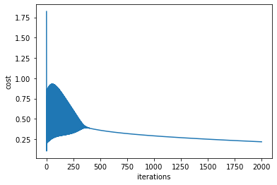

```python
plt.plot(costs)
plt.ylabel('cost')
plt.xlabel('iterations')
plt.show()
```

**f) Prediction**

We then use the optimized parameters to make predictions both for the train and test sets and compute the accuracy for each.

We observe that the value of the accuracy is higher for the training set than the testing set, which is logical because the parameters were optimized using the training data (i.e the model is more adapted for the training data). However this may also indicate overfitting.

```python
def predict(w, b, X):

    y_pred = neuron(w,b,X)
    return y_pred

# predict
train_pred_y = predict(w, b, train_x)

test_pred_y = predict(w, b, test_x)
print("Train Acc: {} %".format(100 - np.mean(np.abs(train_pred_y - train_y)) * 100))
print("Test Acc: {} %".format(100 - np.mean(np.abs(test_pred_y - test_y)) * 100))
```

```
Train Acc: 88.07297429646448 %
Test Acc: 64.85413987167692 %
```

**g) Early stopping**

In order to avoid overfitting we will use early stopping method. To do this we will take a part of the training set for validation. At each iteration of the gradient descent function we will compute the cost for the training set and the validation set, use the first one to update the parameters and the second one to avoid overfitting ( i.e keep updating if the validation cost is still decreasing and stop if not)

We will also use the validation set to chose hyperparameters (learning_rate, iterations) that give the best results

We will start by adapting the gradient descet function to include early stopping

```python
from sklearn.model_selection import train_test_split

def gradient_descent_early_stopping(X, Y, iterations, learning_rate, percentage):

    Ntrain = np.rint((1-percentage)*X.shape[1]).astype(int)
    Nvalid = X.shape[1]-Ntrain
    train_x = X[:,:Ntrain]
    val_x = X[:,Ntrain:]
    train_y = Y[:,:Ntrain]
    val_y = Y[:,Ntrain:]

    w, b = initialize_parameters(train_x.shape[0])


    train_costs=[]
    val_costs=[]
    w_best=w
    b_best=b
    k=0

    for i in range(iterations):


        Ypred_train = neuron(w,b,train_x)
        Ypred_val = neuron(w,b,val_x)
        train_cost = crossentropy(train_y,Ypred_train)
        #print(train_cost)
        train_costs.append(train_cost)
        val_cost = crossentropy(val_y,Ypred_val)
        #print(val_cost)
        val_costs.append(val_cost)

        grads= backpropagate(train_x, train_y, Ypred_train)

        #update parameters
        w = w - learning_rate*grads["dw"]
        b = b - learning_rate*grads["db"]

        if i>0:
            if val_cost < val_costs[-2]:
                w_best=w
                b_best=b
                k=i

    return k,w_best,b_best,train_costs,val_costs
```

**train and validation curves**

Bellow we have the train and the validation curves as well as the iteration at which we get the best parameters

We can see that overall (neglecting the fluctuations ) the train curve is decreasing, while the validation curve decreases then starts increasing after a certain iteration (734 in this case) which indicates the beginning of overfitting

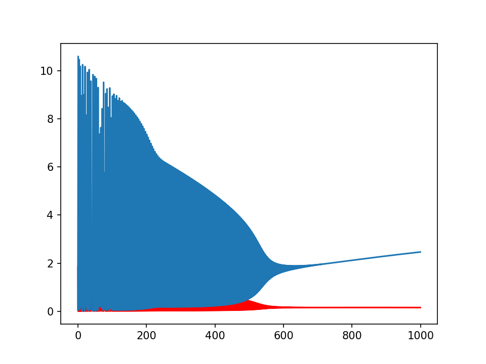

```
734
```

```python
%matplotlib notebook
k,w_best,b_best,train_costs,val_costs=gradient_descent_early_stopping(train_x, train_y, 1000, 0.01, percentage=.1)
plt.plot(train_costs, 'r')
plt.plot(val_costs)
print(k)
```

**The new accuracies**

We compute the accuracy of the train and test sets after adding early stopping, which gives the results bellow.

We observe that the train accuracy has decreased while the test accuracy increased which illustrates the bias-variance tradeoff

```python
#Prediction using w_best and b_best
train_pred_y = predict(w_best, b_best, train_x)

test_pred_y = predict(w_best, b_best, test_x)
print("Train Acc: {} %".format(100 - np.mean(np.abs(train_pred_y - train_y)) * 100))
print("Test Acc: {} %".format(100 - np.mean(np.abs(test_pred_y - test_y)) * 100))
```

```
Train Acc: 85.63255466289995 %
Test Acc: 67.45106627766077 %
```

**Hyperparameter tuning**

with learning rate = 0.1 and nb of iterations = 1000 , we obtain : Train Acc: 93.83777091860054 % Test Acc: 75.1874473114253 %

with learning rate = 0.01 and nb of iterations = 1000 , we obtain : Train Acc: 85.63397157684986 % Test Acc: 67.46263419960974 %

with learning rate = 0.001 and nb of iterations = 1000 , we obtain : Train Acc: 60.9481042288448 % Test Acc: 52.74046839563947 %

In the three cases the stopping occurs before reaching 1000 iterations

We notice that we obtain better accuracies for the learning rate 0.1. However we may need to check other performance measures to better chose the hyperparameters

### 2. CNNs with Keras

Adapt the example in this website https://keras.io/examples/vision/mnist_convnet/ to our problem. To this end:

- change the number of classes and the input size
- remove the expand_dims(x_train, -1): it is not necessary to expand the dimensions since our input is 3-dimensional
- you may need to transpose the labels vector
- change the categorical cross-entropy to the binary cross entropy given that our problem is binary classification.
- also change the softmax to sigmoid, the more appropriate activation function for binary data

We can choose a single neuron output passed through sigmoid, and then set a threshold to choose the class, or use two neuron output and then perform a softmax.

**2.1** Can you get the accuracy better than in our hand single-neuron model?Try different configurations and explain the changes you have made.

**2.2** Compute the train and test loss and accuracy after the model has been trained. What model parameters does the `fit` function retain?

**2.3** How many parameters does the network have, explain where the number comes from.

**2.4** What is the receptive field of the network https://distill.pub/2019/computing-receptive-fields/

```python
import numpy as np
from tensorflow import keras
from tensorflow.keras import layers
```

```python
# the data, split between train and test sets
x_train, y_train, x_test, y_test, classes=load_dataset()

# Model / data parameters

num_classes=2
input_shape=(64,64,3)

# Scale images to the [0, 1] range
x_train = x_train.astype("float32") / 255
x_test = x_test.astype("float32") / 255

# convert class vectors to binary class matrices

y_train = y_train.T
y_test = y_test.T

y_train = keras.utils.to_categorical(y_train, num_classes)
y_test = keras.utils.to_categorical(y_test, num_classes)
```

```python
print(x_train.shape)
```

```
(209, 64, 64, 3)
```

```python
#build the model
model = keras.Sequential(
    [
        keras.Input(shape=input_shape),
        layers.Conv2D(32, kernel_size=(3, 3), activation="relu"),
        layers.MaxPooling2D(pool_size=(2, 2)),
        layers.Conv2D(64, kernel_size=(3, 3), activation="relu"),
        layers.MaxPooling2D(pool_size=(2, 2)),

        layers.Conv2D(128, kernel_size=(3, 3), activation="relu"),
        layers.MaxPooling2D(pool_size=(2, 2)),
        layers.Conv2D(256, kernel_size=(3, 3), activation="relu"),
        layers.MaxPooling2D(pool_size=(2, 2)),

        layers.Flatten(),
        layers.Dropout(0.5),
        layers.Dense(num_classes, activation="sigmoid"),
    ]
)
model.summary()
```

```
Model: "sequential"
_________________________________________________________________
 Layer (type)                Output Shape              Param #
=================================================================
 conv2d (Conv2D)             (None, 62, 62, 32)        896

 max_pooling2d (MaxPooling2D  (None, 31, 31, 32)       0
 )

 conv2d_1 (Conv2D)           (None, 29, 29, 64)        18496

 max_pooling2d_1 (MaxPooling  (None, 14, 14, 64)       0
 2D)

 conv2d_2 (Conv2D)           (None, 12, 12, 128)       73856

 max_pooling2d_2 (MaxPooling  (None, 6, 6, 128)        0
 2D)

 conv2d_3 (Conv2D)           (None, 4, 4, 256)         295168

 max_pooling2d_3 (MaxPooling  (None, 2, 2, 256)        0
 2D)

 flatten (Flatten)           (None, 1024)              0

 dropout (Dropout)           (None, 1024)              0

 dense (Dense)               (None, 2)                 2050

=================================================================
Total params: 390,466
Trainable params: 390,466
Non-trainable params: 0
_________________________________________________________________
```

```python
#comiple and fit
batch_size = 128
epochs = 100
#print(x_train.shape)
#print(y_train.shape)


model.compile(loss="binary_crossentropy", optimizer="adam", metrics=["accuracy"])

model.fit(x_train, y_train, batch_size=batch_size, epochs=epochs, validation_split=0.005)
```

```
<keras.callbacks.History at 0x1d0b71dc0d0>
```

```python
#evaluate


#prediction using keras model
yPred_train = model.predict(x_train)
#print(yPred_train)
yPred_test = model.predict(x_test)

#calculate the accuracy of the model
cost_train    = keras.metrics.Accuracy()(y_train, yPred_train).numpy()
cost_test    = keras.metrics.Accuracy()(y_test, yPred_test).numpy()

#printing thte result
print(cost_train)
print(cost_test)

print("Train Acc: {} %".format(100 - np.mean(np.abs(y_train - yPred_train)) * 100))
print("Test Acc: {} %".format(100 - np.mean(np.abs(y_test - yPred_test)) * 100))
```

```
0.1770335
0.07
Train Acc: 98.83987866342068 %
Test Acc: 84.5709428191185 %
```

**Results**

```python
print('the number of layers is ' + str( len(model.layers) ))

for i in range(len(model.layers)):
    print(f"the number of parameters of the layer {i} is {len(model.layers[i].get_weights())}")
```

```
the number of layers is 11
the number of parameters of the layer 0 is 2
the number of parameters of the layer 1 is 0
the number of parameters of the layer 2 is 2
the number of parameters of the layer 3 is 0
the number of parameters of the layer 4 is 2
the number of parameters of the layer 5 is 0
the number of parameters of the layer 6 is 2
the number of parameters of the layer 7 is 0
the number of parameters of the layer 8 is 0
the number of parameters of the layer 9 is 0
the number of parameters of the layer 10 is 2
```